# [OpenAI – ChatGPT and Codex – Coding with AI](https://fellows.fablearn.org/openai-chatgpt-and-codex-making-with-ai/)

# [Children’s lived experiences an integral part of maker-space](https://fellows.fablearn.org/childrens-lived-experiences-an-integral-part-of-maker-space/)

Posted March 30, 2022 by Ridhi Aggarwal

The people are the driving force of a maker space in a traditional rural community. Thus what we do and how we do both need to incorporate the cultural and contextual aspect of the community. This was the starting point of the recent set of activities that were driving our curriculum at Ramdwari Khojshala (makerspace). As in the words of a parent the maker space was a place where children go and do some fixing, repairing and breaking and they make things which were sometimes of use to the community. This motivated us to make a list of things which needed repairing in the community and was done by the community members by themselves. This way we were looking at a maker culture that already existed in the community. Using this traditional knowledge of the community we wanted to build upon it. When we compiled the lists we saw the things which came on all the lists were a cycle, a handpump and an Umbrella.

This was the starting point of our object based maker learning. As we know that people make things, from hand fans to telescopes, people throughout history and across cultures, contexts have been designing and making objects for everyday use. Objects are of different types they are practical or decorative, simple or complex. Some are crafted by hand while others can be manufactured by machine. On the other hand they can be made in a few minutes or can be built across generations. Usually objects are made by particular people for particular purposes although their use often extends beyond their makers’ original intentions. Even the simplest objects reflect the culture and more importantly the context (social and physical )in which they were created as well as the contexts in which they continue to be used. A close observation of these everyday objects not only sparks students’ curiosity but leads to increasingly complex thinking.

So we started with a cycle that children used everyday and have seen the people around them repair it as well. The first step was to encourage students to make careful observations of the cycle as It helps stimulate curiosity and sets the stage for inquiry. They have to draw the picture by looking closely at its parts like nuts, bolts, rods etc. After drawing the picture they had to talk about the cycle of what they observed and write down about the parts their purpose and the complexities of all of them coming together.

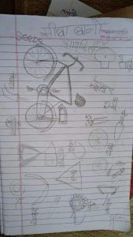

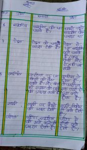

Observation led to exploration of the mechanism of the wheels, pedals etc. and the children tried making it with paper, cardboard to explore how the movement happens. This intrigued their mind as to how this parts were installed together so that they move and the cycle comes in motion. Children has many questions around the same so this gave us the opportunity to include one more task which we had not planned which was Take-Apart, so now they took apart all the parts of the cycle and re-build it (putting it together). The real reflections came in when they compared what they thought a part did and what it could actually do when they were assembling the parts.

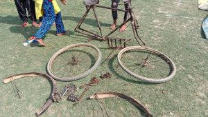

As we were trying to include the contextual making culture so we thought to share some stories, well not only for fun but for empowerment. So we had 2 stories : 1) Cycling as a social movement for rural women in Pudukkottai district of Tamil Nadu 2) The amphibious bicycle (a bicycle turning into a boat)

These two stories emerged a good discussion amongst students, one of them in her reflection said that “if we could break various objects and understand their working and then combine different parts of different objects we might be able to make things which we can’t afford or we need them but they don’t exist”. This reflection was the point where each student wanted to know what they wanted to make with the parts of the cycle, sometimes discussions lead to new beginnings. The next day the class went around the village looking for solutions in their neighbourhood which were Jugaad (a term used in India for things which are repurposed or something like a indigenous object made by them for a particular purpose) and they saw a list of objects and problems to which they wanted to look for solutions.

Two weeks into the maker space and there were 8 projects that came up with the parts of the cycle which would be useful for the community. I would like to show the prototypes of a few of them :

1. There was a problem to ride the bicycle in night due to lack of light on the village roads. Jasmeen, one of our student had thought if she could attach a light which can glow when someone peddles the bicycle, then it will be great. She made a small prototype in which she attached a motor, a bulb, some wires are fixed in the bicycle. The motor is attached with the crank and when the force is applied to the pedal, the chain wheel moves and in turn the motor moves which gives energy to the bulb.

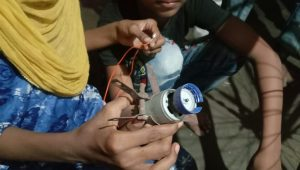

2. To cut grass/weeds on the agricultural field is always a problem. Therefore Nazia, our student have thought if she attach a sharp blade from the front hub of the bicycle then she and others can easily cut the small and medium size grass/weeds by manoeuvring the handlebars of the bicycle. This will take less time and less effort and would cut the grass from the roots easily.

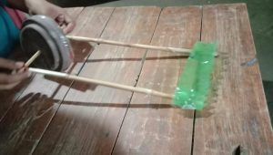

3. Rabia, one of our student has made a model to cut the grass/fodder with a fan attached with a rod and the rod is attached with the front part of the bicycle. The same fan like structure is available which runs on electricity but since there is erratic supply of electricity in the village, the student thought of making a design which can work with bicycle. The grass/fodder which after cutting can be given to livestock as food for their nutrition.

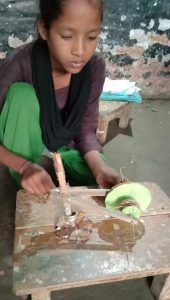

4. Lakshmi, Jaid and Raja, 3 students have made a bicycle-enabled pesticide spraying machine in which when you peddle the wheel the pesticide from the tank which is kept on the carrier comes out through a sprinkler attached on the front part of the bicycle. Through this attachment, one can save lot of time and effort. There are machines which run on battery but buying and maintaining them is a costly affair therefore students have thought about this solution.

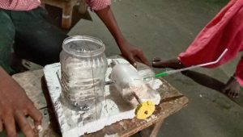

5. One of our student attached a wiper through the front part of the wheel. During rains when the drains overflow, it becomes very difficult to ride the bicycle on swampy roads. Through this innovation when you are riding the bicycle, the sludge and the mud on the road could be moved to the sides of the road allowing movement on the bicycle. This could also prevent accidents due to balancing issues.

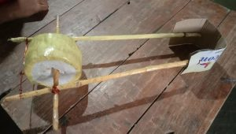

6. Noor Jahan & Shabana attached a fan with gears and levers with a bicycle. This fan with gears would help in going towards the water table so that water could be taken out for irrigation purposes. Also, it could also help in making drinking water available to the households. There are engines already available but that runs on petrol or diesel which is a costly affair and also add pollution to the environment.

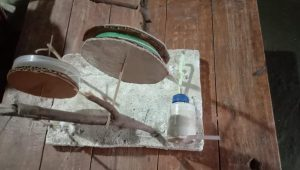

7. Aafia and Sana, 2 students have thought of cleaning the village drains with an accumulator and tank behind the bicycle. While in rains, the drains used to choke which leads to overflowing of water and mud on the road, making roads extremely slippery and highly prone to accidents. With this innovation, the mud and sludge could be collected in the collector and discharged in the open space helping in cleaning the drains.

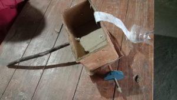

8. Naseem and Alisha made a bicycle-enabled handpump in which the instead of a handle the pump rod is attached with the crank of the bicycle. When one peddles, the crank moves which in-turn helps in moving the piston rod. When the piston rod moves up and down it helps in taking water out from the outlet thereby reducing the time and effort.

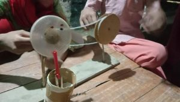

Apart from all this children also did a survey of the number of cycles in the village and how many girls have a bicycle. They found that very few girls knew how to ride a bicycle o they decided to start a bicycle club where girls would learn to ride and they could rent a bicycle for purposes of mobility and emergencies.

Things often do not go the way we plan them and they take their own flow. But as a teacher I would admit that there were moments when I wanted to get into the discussion and make a point but my patience was at test, also after all these years I have understood that its not necessary that things would go as you plan but if the framework is going as you planned then what ever way it goes its ok. As when things take their own flow especially if the flow is guided by children then the content is owned by them and learning is deep. As teachers we come to our classrooms day after day with our burden of knowledge tucked under our arms or carried in our heads but If we stick to this identity then the atmosphere of the classroom would be defined largely by our authority. we need to see and face our own limitations and biases. When a teacher say, “I don’t know… I am also learning” that is when students respond freely, then knowledge or the lack of it is no longer a threat to personal selfhood. Only when student and teachers are in a relationship of learning together there is a release of creative energy. This was the essence of this lesson which brought forward students agency and ownership on their learning.

Cycle as an object offered a tactile experience for students, which challenged them to observe and conceptualise their thinking. While the teacher facilitates the session, the students construct meaning for themselves through their interactions with each other centred around the object ([Hannan et al., 2013](http://f1000research.com/articles/5-61/v2#ref-14)). It represents a social constructivist approach therefore in which the students develop their knowledge and understanding though interaction with objects based on a prior understanding ([Chatterjee & Hannan, 2015](http://f1000research.com/articles/5-61/v2#ref-10)). This approach enables the student to explore ideas, processes and events related to the object and further gives them an opportunity to build upon their ideas. Communities making culture and inputs along with students interactions was the key focus of the session . So we can say that the extent to which students are provided opportunities to interact and explore about disciplinary ideas as well as to build on others’ ideas and have others build on theirs provides a big opportunity for student empowerment. Thus we can say that the object not only focused on learning concepts or exploring way of making and fabrication it also was a way that could contribute to children’s development of agency (the willingness to engage), their ownership over the content, and the development of positive identities as thinkers and learners.

# [our robotics workshop for children](https://fellows.fablearn.org/our-robotics-workshop-for-children/)

Posted March 27, 2022 by Mouhamadou Ngom

## **our robotics workshop for children**

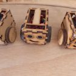

[figure not shown]

**SENFABLAB** is a space for creativity, learning, prototyping and sharing. Located in **Grand**–**Yoff**, a popular neighborhood It aims to spread digital technologi,s and to promote learning and training through practice. Its main objective is to engage young people, women, craftsmen and people with reduced mobility in the use of computers and digital technologies.

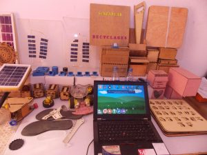

[figure not shown]

*Picture of the lab*

**Senegal’s Senfablab**, in partnership with the company Samarabot (My Robot), -has set up Robotics clubs to welcome and initiate children aged 7 to 15 into robotics and computing. The objective is to allow them to become familiar with physical computing so they can have the same opportunities as those in residential areas.

We use the free educational software for children called [GCompris](https://www.gcompris.net/index-fr.html). Young people start their learning by using the keyboard and the mouse with G-Compris, learning to hold the mouse straight and then to make clicks (right, left, and the wheel). The objective is to move the mouse to erase the blocks and make a drawing appear.

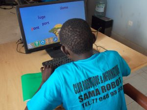

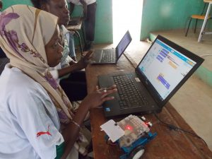

After this session of learning the mouse, they use the keyboard to write the letters. The goal is to type the words that go down, before they touch the ground.

Then we introduce programming with [Scratch](https://scratch.mit.edu/), which is very useful to learn programming through blocks. After mastering the Scratch interface, **Kene**, the educator, asks them to think and then design a scenario.

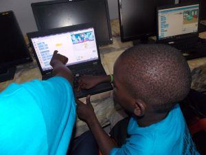

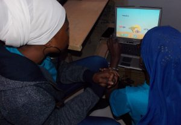

Level 01 is led by **Kene** and **Salma** who are in charge of the children’s first learning in the lab. We work with a group of children every Wednesday between 4 and 6 pm in the lab. On Saturdays, a team goes to the schools with **Bamba**, to teach robotics. There are children who live in the neighborhood, but also others who live between 10 and 20 km from the lab.

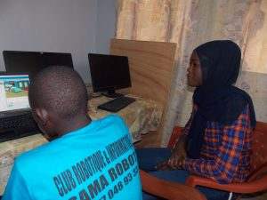

[figure not shown]

The children can stay for hours, without even realizing it, because the classes are interesting for them. They learn by playing.

Currently we are setting up [Lynx](https://lynxcoding.club/) which we discovered with the **Fablearn** **Fellows** and will be taught to the children next year.

[figure not shown]

[figure not shown]

# [We need to make the school curriculum more flexible in favor of the Maker Culture](https://fellows.fablearn.org/we-need-to-make-the-school-curriculum-more-flexible-in-favor-of-the-maker-culture/)

Posted March 10, 2022 by Débora Garofalo

I have had the opportunity to work with the maker culture in many ways, at school as a teacher of 24 classes and now at the Education Department working on public training policies for the transformation of Education.

Many teachers have questions about how to work with the do-it-yourself movement. This text is an invitation for reflection on the many possibilities of work and to understand more about the maker universe and to make the school curriculum flexible in favor of the maker doing.

The maker culture is the gateway to work with innovation and it invites students and teachers to learn through experimentation, in addition to allow youth protagonism by stimulating creativity, logical thinking and working trying to solve real problems.

To work with the maker universe, I believe that it is not necessary to have dedicated learning spaces, it is enough to reorganize the furniture, assemble corners with materials and tools and exercise creativity. However, it is important to know that many schools have dedicated spaces in digital format with equipment such as a 3D printer, laser cutter and supplies for robotics but they are all unplugged and the space is used for specific activities that include sewing, embroidery, woodworking, animation, 3D modeling with playdough and others.

**Being a maker is, above all, having an attitude and transforming the class into collaborative learning!** It is carrying out activities and living experiences, in this way, it ends up being a great umbrella for working with computational thinking.

I have recently carried out a training with teachers who made a mechanical hand with low resources and I was delighted with what the teacher did, he turned this learning into a robotic hand for the children of the early years to work with motor coordination and or for those who do not have movements. This is magic!

[figure not shown]

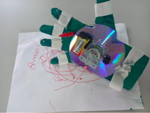

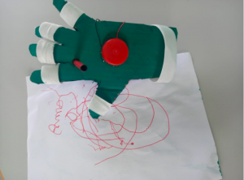

**Making the school curriculum flexible**

Culture does not replace the school curriculum, but it encourages you to do it in a different format! I can work in a history class with the central theme about Egypt and for that to play storytelling with the students and create games from [scratch](https://scratch.mit.edu/). And or I can work in the science discipline the environmental issue and address the recycling of materials and from this work to mobilize other areas of knowledge in this construction, but without losing the essence, of talking about the environmental issue and the time taken by materials to decompose.

Therefore, it is necessary to look at the school curriculum and understand that the maker culture is an ally to make it more attractive and meaningful to students, in addition to allowing the transformation of theory into practice; make learning meaningful and a more practical curriculum; experiencing learning in a singular and plural way and encouraging scientific thinking.

There are many benefits when working with the maker culture allied to the school curriculum, in addition to the opportunity to revolutionize Education by allowing youth protagonism and a meaningful education for all!